# Aside

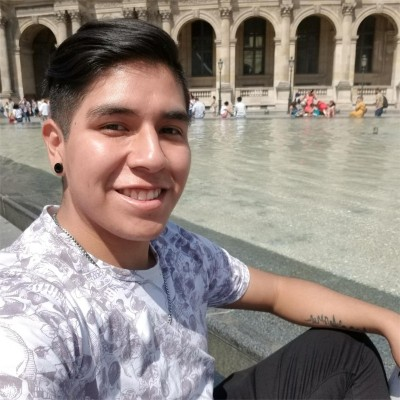

## Contacto

cristian.ncz1998@gmail.com

github.com/Najucove98

[+549 341-3888957](https://wa.me/5493413888957?text=Hola!%20Vi%20tu%20CV%20y%20me%20gustaria%20contactarte)

Para más información, por favor póngase en contacto conmigo vía correo electrónico.

## Habilidades

- Conocimientos básico en estadística descriptiva, análisis multivariado, inferencial, análisis de datos.
- **Software estadístico:** R, Python, SAS.
- **Visualización de datos:** R Shiny, Power BI.

# Main

## Cristian Nahuel Coveñas Zavaleta

### Estudiante de Licenciatura en Estadística

Estudiante avanzado con manejo de modelos lineales, análisis multivariado y programación en R. Experiencia en el desarrollo de herramientas interactivas con Shiny y automatización de reportes.

## Educación

### Primario completo

Escuela N.º 55 DOMINGO FAUSTINO SARMIENTO

Rosario

### Secundario completo

Escuela Normal Superior N.º 1 – Dr. Nicolás Avellaneda

Rosario

### Universitario cursando

Facultad de ciencias económicas y estadística

Rosario

2021 - Actualidad

Cursando 4º año de Licenciatura en Estadística - Turno mañana

## PROYECTOS DE ANÁLISIS

### Dashboard Interactivo de Tráfico Web

Desarrollo de una aplicacion web en Shiny. [**Link**](https://naju-shinyapp.shinyapps.io/Aranda_Covenias/)

FCEyE

2025

- Monitoreo y análisis de métricas de tráfico web.
- Aplicación de una interfaz dinámica mediante `bslib` y `shinyWidgets`.
- Visualización de datos geoespaciales y temporales integrando `echarts4r`.

### Análisis de Datos Multivariado (NBA)

Estudio de perfiles de rendimiento (1980-2000). [**Base**](https://www.kaggle.com/datasets/drgilermo/nba-players-stats)

FCEyE

2025

- Aplicación de tecnicas multivariadas para la reducción de dimensionalidad e identificación de patrones de juego.
- Limpieza y preprocesamiento de datos con `tidyverse`.
- Interpretación de resultados para la caracterización de jugadores.

## Experiencia Docente

### Programación 1.

Ayudante de cátedra en programación 1.

FCEyE

2025 - 2026

- Facilitar el aprendizaje de conceptos de lógica de programación y estructuras de datos en comisiones de trabajos prácticos.
- Brindar mentoría técnica y resolución de dudas para el desarrollo de proyectos (TP).